# Jornada_16S

Nat Pombubpa

### STEP1: Load all necessary packages for analysis using Phyloseq

More information about Phyloseq can be found at the following link: [Phyloseq](https://joey711.github.io/phyloseq/)

If you get error in this step, you probably need to install any packages which causes error.

```r
library(phyloseq)
library(microbiomeSeq)
library(ape)
library(vegan)
library(reshape2)
library(ggplot2)
library(igraph)
library(gridExtra)
library(grid)
library(plyr)
```

### STEP2: Import Mapping file (metadata file)

1.Check mapping file before import to R, R doesn’t seem to like sample name to start with number or contain “-” in sample name. If you get error in this step, you should check file name first.

2.First column of first row should not start with #, R will not read the first row that starts with #

```r
meta = read.table("050517NP515F-mapping2_NP_1_30.txt",header=TRUE,row.names=1,sep="\t",stringsAsFactors=FALSE)
```

### STEP3: Check if your metadata file has been import sucessfully and correctly

The output will show a table of your metadata file (mapping file).

*If you do not have header, you might start your first row with #

```r
head(meta)
```

```
##   BarcodeSequence LinkerPrimerSequence BarcodeName  ProjectName
## 1        GAGAGTGT  GTGCCAGCMGCCGCGGTAA    515Fbar1 050517NP515F
## 2        GAGATCAG  GTGCCAGCMGCCGCGGTAA    515Fbar2 050517NP515F
## 3        GAGATCTC  GTGCCAGCMGCCGCGGTAA    515Fbar3 050517NP515F
## 4        GAGATGAC  GTGCCAGCMGCCGCGGTAA    515Fbar4 050517NP515F
## 5        GAGATGTG  GTGCCAGCMGCCGCGGTAA    515Fbar5 050517NP515F
## 6        GAGTACAG  GTGCCAGCMGCCGCGGTAA    515Fbar6 050517NP515F
##   Description            SampleName VegZone Disturbance
## 1           1    T-East Undisturbed Tarbush Undisturbed
## 2           2      T-East Disturbed Tarbush   Disturbed
## 3           3   T- West Undisturbed Tarbush Undisturbed
## 4           4     T- West Disturbed Tarbush   Disturbed
## 5           5 T- Taylor Undisturbed Tarbush Undisturbed
## 6           6   T- Taylor Disturbed Tarbush   Disturbed
```

### STEP4: Construct sample_data-class using imported metadata

```r
sampleData <- sample_data(meta)
```

### STEP5: Import otu table

Otu table from Jornada 16S data is “Sam1_34a.otu_table.txt”.

```r
otus <- read.table("Sam1_34a.otu_table.txt",header=T,sep="\t",row.names=1)
otumat <- as(as.matrix(otus), "matrix")
OTU = otu_table(otumat, taxa_are_rows = TRUE)
```

Check imported OTU table

```r
head(OTU)
```

```
## OTU Table:          [6 taxa and 34 samples]
##                      taxa are rows
##          sa1 sa10 sa11 sa12 sa13 sa14 sa15 sa16 sa17 sa18 sa19  sa2 sa20
## OTU1    1788   12  189 1319 1289 1619    8    3   16   33 1212 2176  153
## OTU10    173  336  245  289  103  197  290  151  727 1072  225  205  409
## OTU100    26   31   54   93    5   10   12   15   38   26   30   27   24
## OTU1000    3    0    0    0   14    2    1    0    1    4    0    8    0
## OTU1001    4    2    3    6    3    3   45   40    6   28    3   17    4
## OTU1002    4   12   10    4    1    0    0    0    1    1    8    4    7
##         sa21 sa22 sa23 sa24 sa25 sa26 sa27 sa28 sa29 sa3 sa30 sa31 sa32
## OTU1     201  499   11    3   85   23  228  258 1209 902  643 1851 1658
## OTU10    200  257  165  228  518 1001  433  141  668 144  415  250  177
## OTU100    17   30   20   24   83   95   39   40   55   9   76   18   26
## OTU1000    0    0    1    0    0    0    0    0    0   3    0    6    0
## OTU1001   14    5   17   19    8    9    2    1    6   2    6    4   19
## OTU1002   14   16   10    3   19    7   13    7   12  18    7    4    9
##         sa33 sa34  sa4 sa5  sa6 sa7 sa8 sa9
## OTU1     117  337 1103 616 1064 254 303  16
## OTU10    285  272  150 107   73 189 243 219
## OTU100    60   34   12  27    7  40  28  48
## OTU1000    0    0    0   6    5   0  10   0
## OTU1001    3   11    5   4    4   8   9   6
## OTU1002    5    7   27   2    1   6   5   1
```

### STEP6: Import taxonomy table

Taxonmy table generated from AMPtk need to be rearranged using following script.

“perl rdp_taxonmy2mat.pl<Input_taxonmy.txt>Output_taxonomy.txt”

rdp_taxonomy2mat.pl was created by Professor Jason E. Stajich

```r
taxmat <- read.table("Sam1_34a.taxonomy.fix.txt", header=T,sep="\t",row.names=1)
taxmat <- as(as.matrix(taxmat),"matrix")
TAX = tax_table(taxmat)
```

### STEP7: Import phylogenetic tree

Phylogenetic tree can also be include for furthur phylogenetic analysis.

```r
treefile = "Sam1_34a.tree.phy"
tree = read.tree(treefile)
```

### STEP8: Construct Phyloseq object

To construct phyloseq object, otu table, taxonomy table, and sampleData are required. Phylogenetic tree can be included, but it is not necessary for constructing phyloseq object.

```r
ps = phyloseq(OTU,TAX,sampleData,tree)
```

Check phyloseq object

```r
ps
```

```
## phyloseq-class experiment-level object
## otu_table()   OTU Table:         [ 8180 taxa and 30 samples ]
## sample_data() Sample Data:       [ 30 samples by 8 sample variables ]
## tax_table()   Taxonomy Table:    [ 8180 taxa by 7 taxonomic ranks ]
## phy_tree()    Phylogenetic Tree: [ 8180 tips and 8179 internal nodes ]
```

### STEP9: Remove singletons

Remove any OTUs that present only one time.

```r
ps.prune = prune_taxa(taxa_sums(ps) > 1, ps)
```

Rarefy otu table to even depth. (This step was not necessary according to the phyloseq author.)

```r
ps.prune.rarefy = rarefy_even_depth(ps.prune, trimOTUs = FALSE)
```

### STEP10: Plot Alpha Diversity using Plot_Richness command

Alpha diversity measure: Shannon (VegZone)

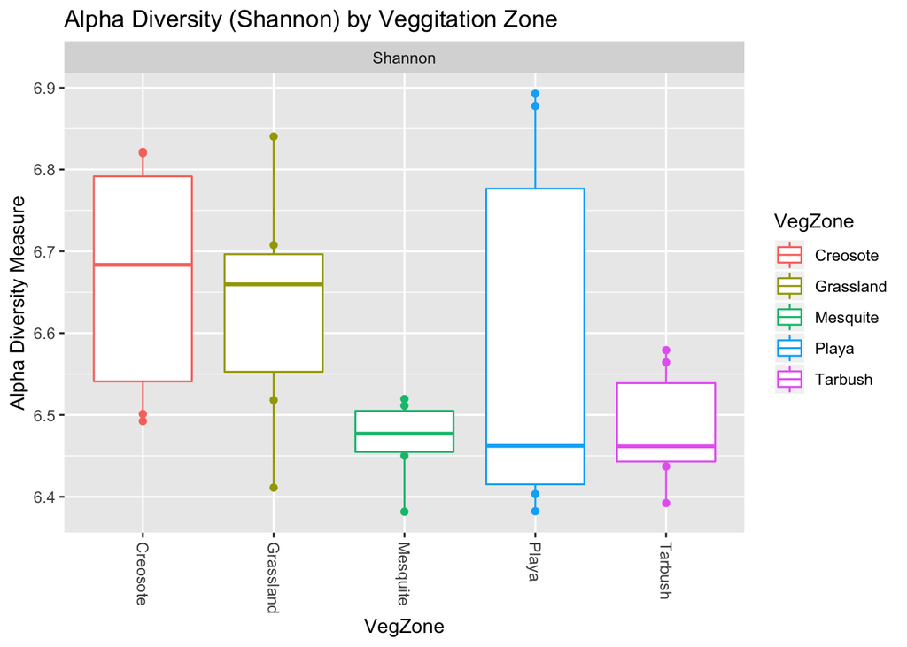

```r
plot_richness(ps.prune.rarefy, x="VegZone", color=("VegZone"), measures=c( "Shannon")) + geom_boxplot() + ggtitle("Alpha Diversity (Shannon) by Veggitation Zone")
```

Alpha diversity measure: Chao1 (VegZone)

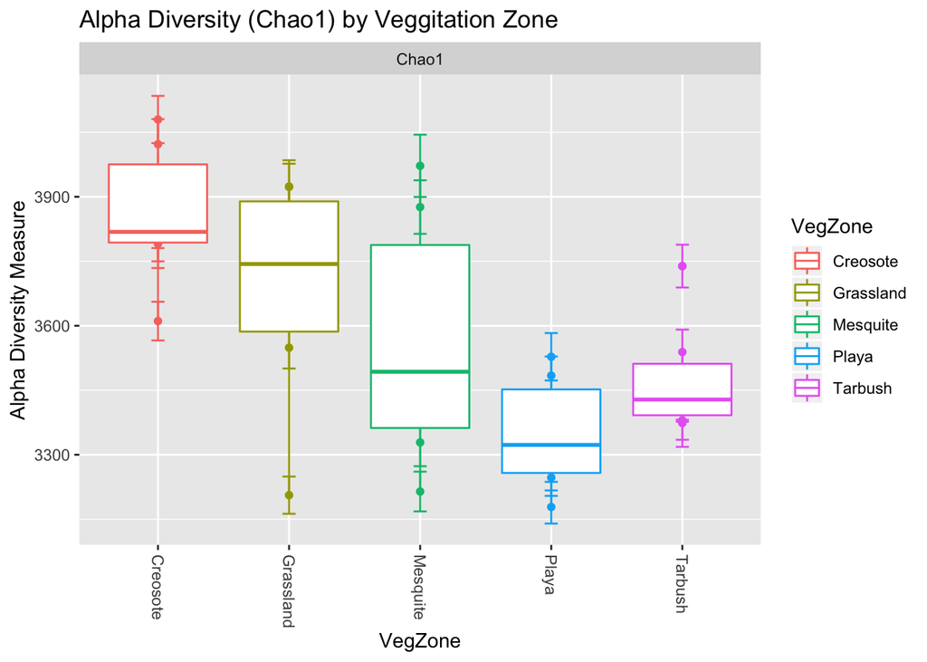

```r
plot_richness(ps.prune.rarefy, x="VegZone", color=("VegZone"), measures=c( "Chao1")) + geom_boxplot() + ggtitle("Alpha Diversity (Chao1) by Veggitation Zone")
```

### Reorder Alpha Diversity X-axis and legend

Use “scale_x_discrete”" to reorder x-axis and “scale_color_discrete”" to reorder legend

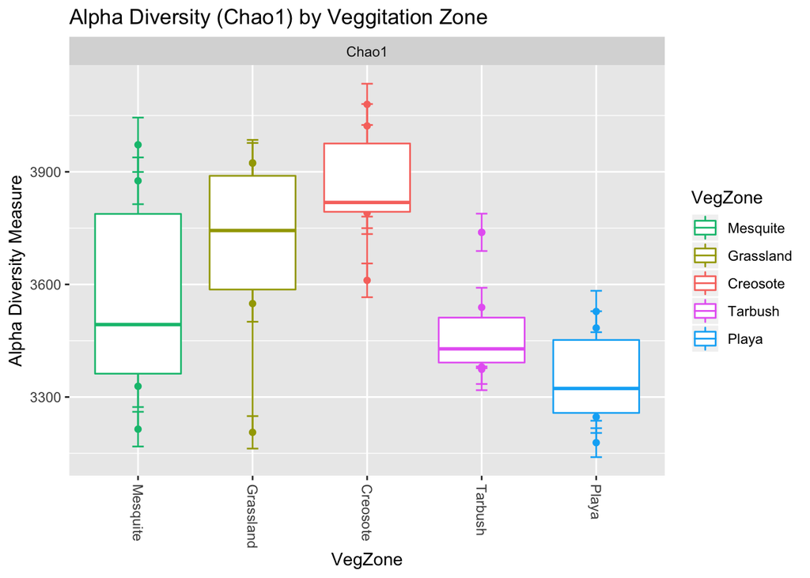

```r
plot_richness(ps.prune.rarefy, x="VegZone", color=("VegZone"), measures=c( "Chao1")) + geom_boxplot() + ggtitle("Alpha Diversity (Chao1) by Veggitation Zone") + scale_x_discrete(limits=c("Mesquite","Grassland", "Creosote", "Tarbush", "Playa")) + scale_color_discrete(breaks=c("Mesquite","Grassland", "Creosote", "Tarbush", "Playa"))
```

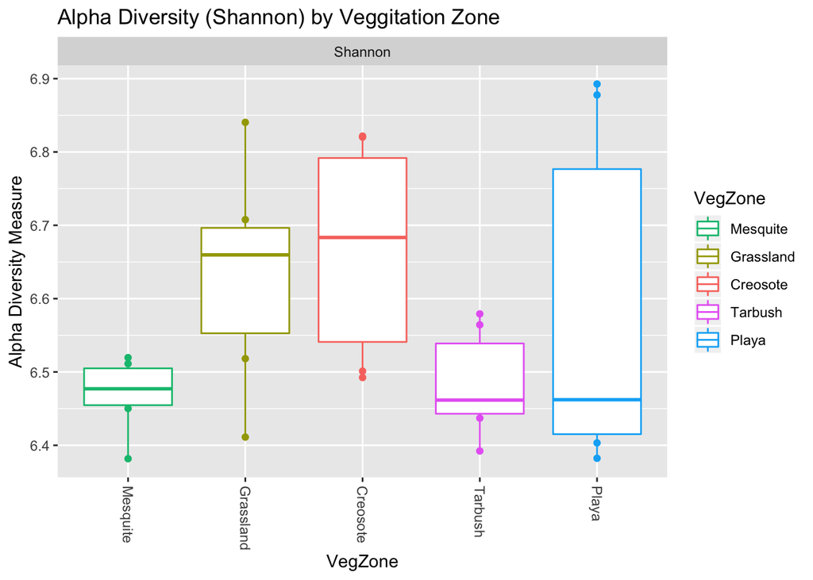

```r
plot_richness(ps.prune.rarefy, x="VegZone", color=("VegZone"), measures=c( "Shannon")) + geom_boxplot() + ggtitle("Alpha Diversity (Shannon) by Veggitation Zone") + scale_x_discrete(limits=c("Mesquite","Grassland", "Creosote", "Tarbush", "Playa")) + scale_color_discrete(breaks=c("Mesquite","Grassland", "Creosote", "Tarbush", "Playa"))
```

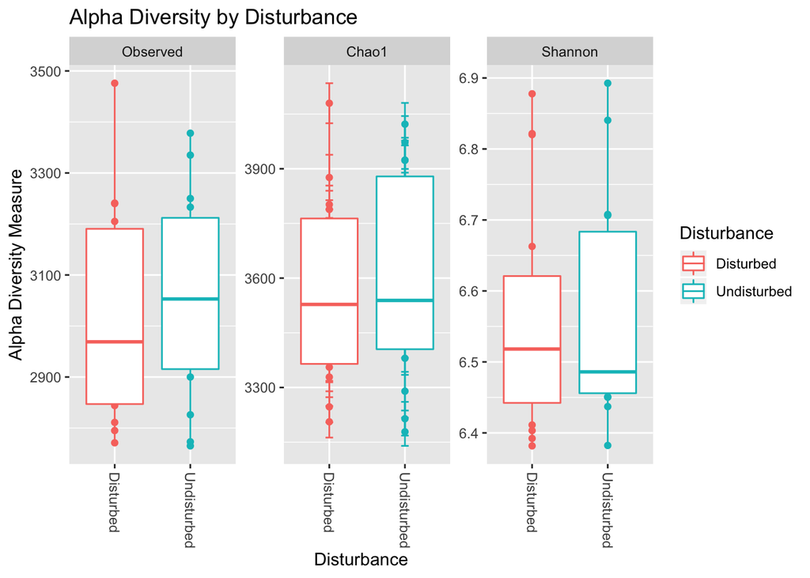

```r
plot_richness(ps.prune.rarefy, x="Disturbance", color=("Disturbance"), measures=c( "Chao1","Shannon", "Observed")) + geom_boxplot() + ggtitle("Alpha Diversity by Disturbance")
```

### STEP11: Calculate distance

```r
ps.ord <- ordinate(ps.prune, "PCoA", "unifrac")
```

### STEP12: Plot ordination

```r
psVegZone = plot_ordination(ps.prune, ps.ord, type = "samples", color = "VegZone") + stat_ellipse(geom = "polygon", alpha = 1/18, aes(fill = VegZone)) + theme_bw() + ggtitle("Beta Diversity (PCoA) by VegZone")
```

### STEP13: Print Plot

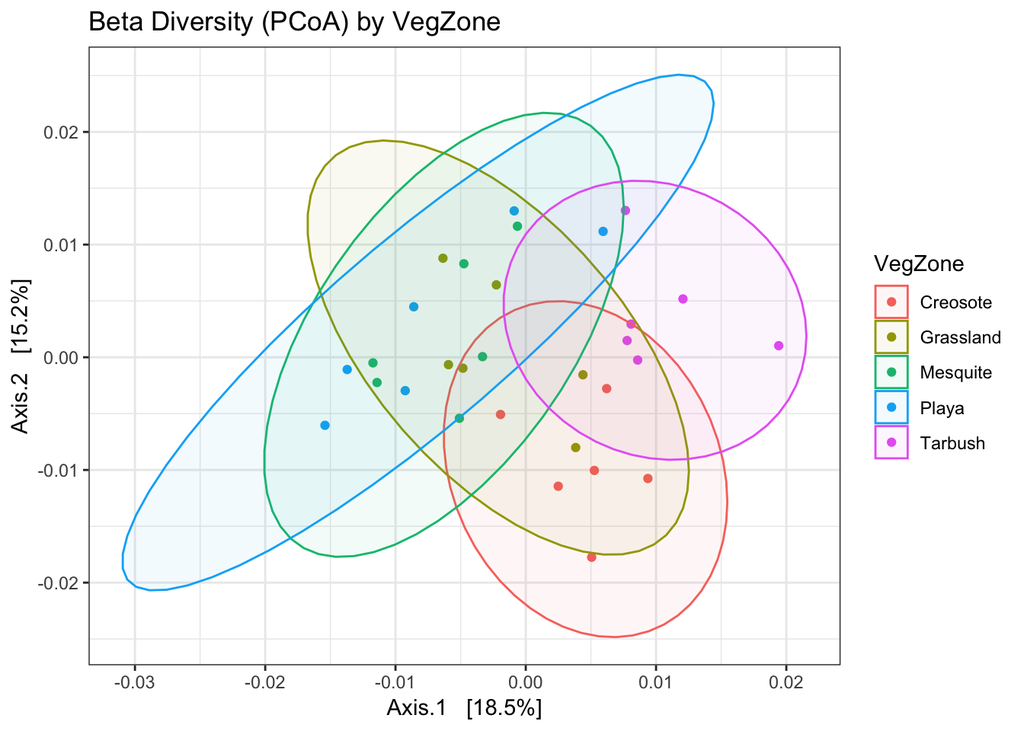

```r
print(psVegZone)
```

```r
psDisturbance = plot_ordination(ps.prune, ps.ord, type = "samples", color = "Disturbance") + stat_ellipse(geom = "polygon", alpha = 1/18, aes(fill = Disturbance)) + theme_bw() + ggtitle("Beta Diversity (PCoA) by Disturbance")
```

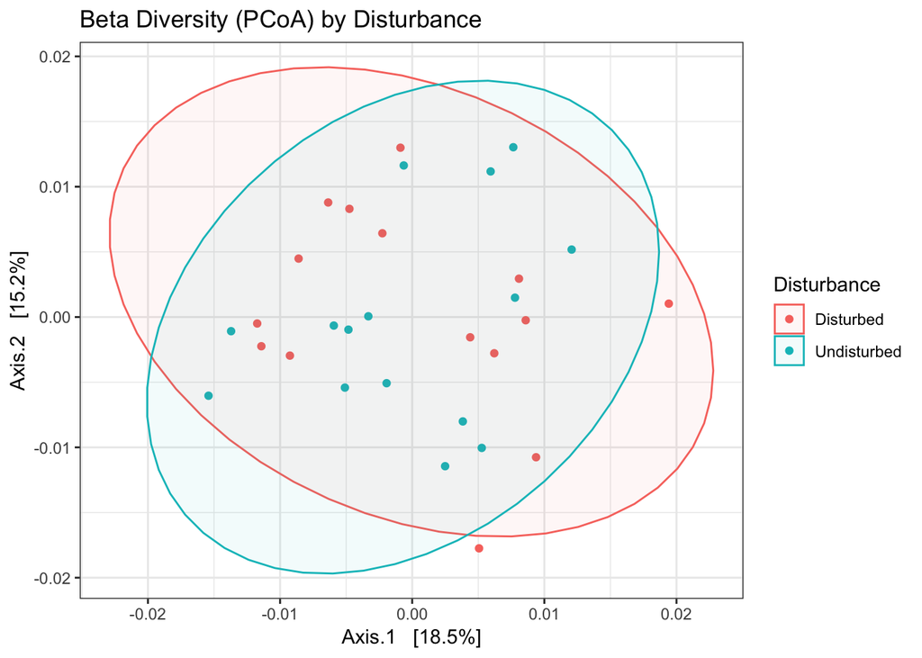

```r
print(psDisturbance)
```

```r
ps.ord <- ordinate(ps.prune, "NMDS", distance="bray")
```

```
## Square root transformation
## Wisconsin double standardization
## *** Solution reached
```

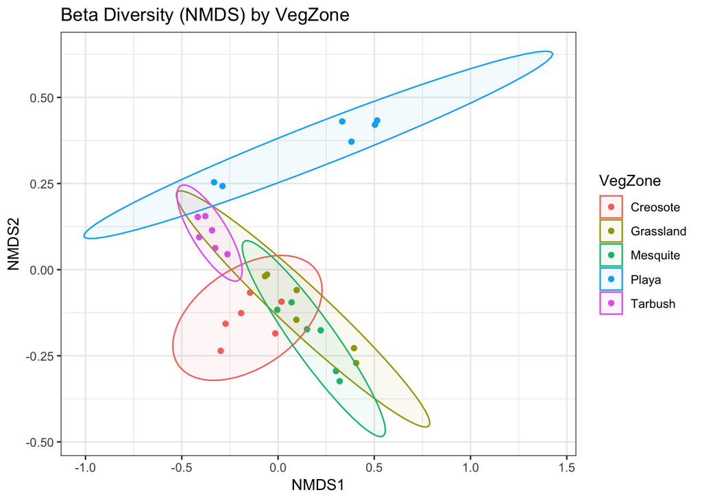

```r
psVegZone = plot_ordination(ps.prune, ps.ord, type = "samples", color = "VegZone") + stat_ellipse(geom = "polygon", alpha = 1/18, aes(fill = VegZone)) + theme_bw() + ggtitle("Beta Diversity (NMDS) by VegZone")
print(psVegZone)
```

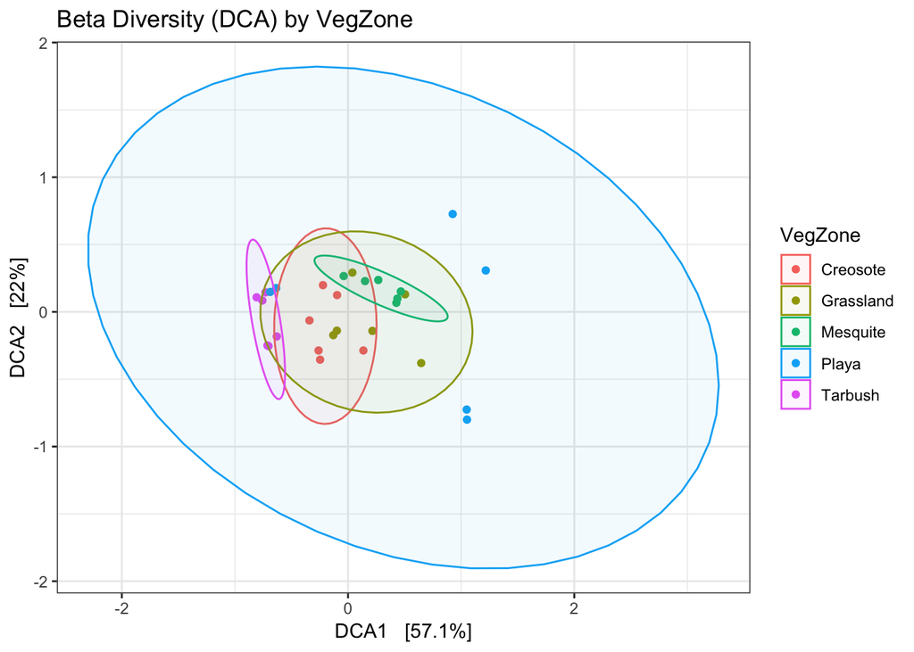

```r
ps.ord.dca <- ordinate(ps.prune, "DCA")
psVegZone = plot_ordination(ps.prune, ps.ord.dca, type = "samples", color = "VegZone") + stat_ellipse(geom = "polygon", alpha = 1/18, aes(fill = VegZone)) + theme_bw() + ggtitle("Beta Diversity (DCA) by VegZone")
print(psVegZone)
```

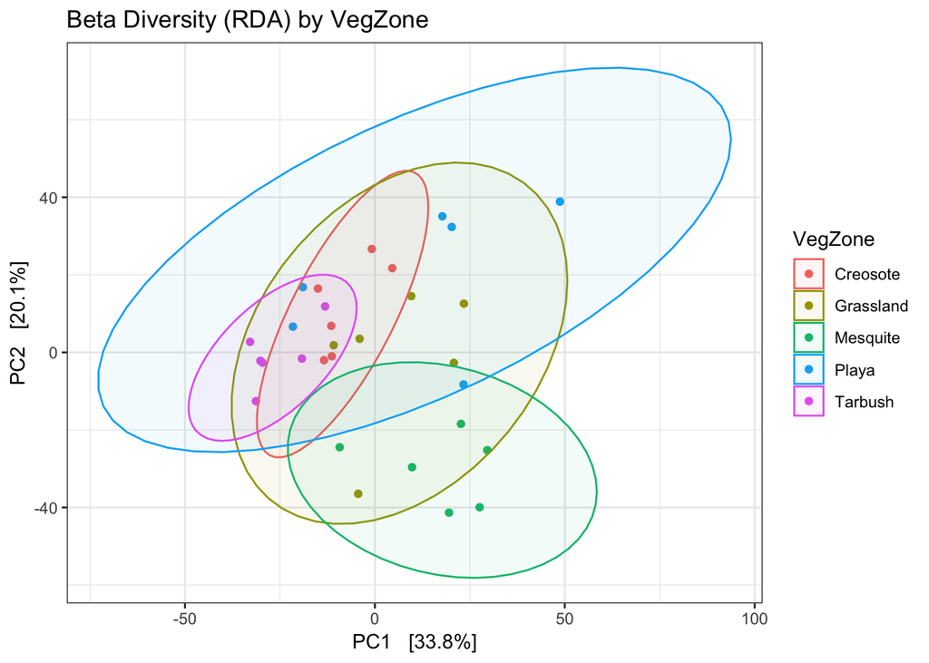

```r
ps.ord.rda <- ordinate(ps.prune, "RDA")
psVegZone = plot_ordination(ps.prune, ps.ord.rda, type = "samples", color = "VegZone") + stat_ellipse(geom = "polygon", alpha = 1/18, aes(fill = VegZone)) + theme_bw() + ggtitle("Beta Diversity (RDA) by VegZone")
print(psVegZone)
```